# Practical Lab 6

## Student Name: `Simardeep Singh`

## Student Roll Number:`8976948`

#### **Q1 Obtain the data using the sklearn load_iris method. Redefine 2 classes for the target variable: virginica and non-virginica (the original dataset includes 3 classes).**

```python
# All Libraries
from sklearn.datasets import load_iris
import pandas as pd
import seaborn as sns
import matplotlib.pyplot as plt
from sklearn.model_selection import train_test_split
from sklearn.linear_model import LogisticRegression
from sklearn.metrics import accuracy_score
import pandas as pd
from sklearn.metrics import roc_auc_score, accuracy_score, precision_score, recall_score, f1_score
import plotly.graph_objects as go
import numpy as np
from sklearn.metrics import confusion_matrix
```

```python
iris_dataset = load_iris()

df = pd.DataFrame(data=iris_dataset.data,columns=iris_dataset.feature_names)
df['target']=iris_dataset.target
df['target']=df['target'].map({0:'non-virginica',1:'non-virginica',2:'virginica'})
print(df.head())
```

```
   sepal length (cm)  sepal width (cm)  petal length (cm)  petal width (cm)
0                5.1               3.5                1.4               0.2  \
1                4.9               3.0                1.4               0.2
2                4.7               3.2                1.3               0.2
3                4.6               3.1                1.5               0.2
4                5.0               3.6                1.4               0.2

          target
0  non-virginica
1  non-virginica
2  non-virginica
3  non-virginica
4  non-virginica
```

#### **Q2 Explore the data**

##### 2.1: 1 table with descriptive statistics for each of the two classes.

```python
descriptive_statistics_ss = df.groupby('target').describe()
print(descriptive_statistics_ss)
```

```
              sepal length (cm)
                          count   mean       std  min    25%  50%  75%  max
target
non-virginica             100.0  5.471  0.641698  4.3  5.000  5.4  5.9  7.0  \
virginica                  50.0  6.588  0.635880  4.9  6.225  6.5  6.9  7.9

              sepal width (cm)         ... petal length (cm)
                         count   mean  ...               75%  max
target                                 ...
non-virginica            100.0  3.099  ...             4.325  5.1  \
virginica                 50.0  2.974  ...             5.875  6.9

              petal width (cm)
                         count   mean       std  min  25%  50%  75%  max
target
non-virginica            100.0  0.786  0.565153  0.1  0.2  0.8  1.3  1.8
virginica                 50.0  2.026  0.274650  1.4  1.8  2.0  2.3  2.5

[2 rows x 32 columns]
```

##### 2.2: 1 Histogram per feature, for each of the two classes. See https://seaborn.pydata.org/generated/seaborn.histplot.html and consider using the `hue` argument to distinguish between classes in the same graph.

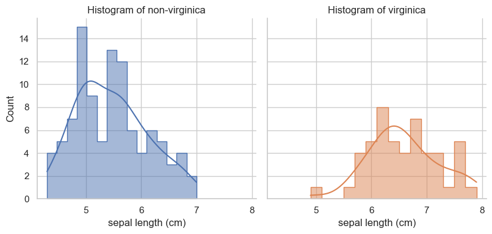

```python
sns.set(style="whitegrid")
hist = sns.FacetGrid(df, col="target", hue="target", col_wrap=3, height=4)
hist.map(sns.histplot, "sepal length (cm)", kde=True, bins=15, element='step')

hist.set_titles("Histogram of {col_name}")

plt.show()
```

##### 2.3: Correlation matrix between the four features

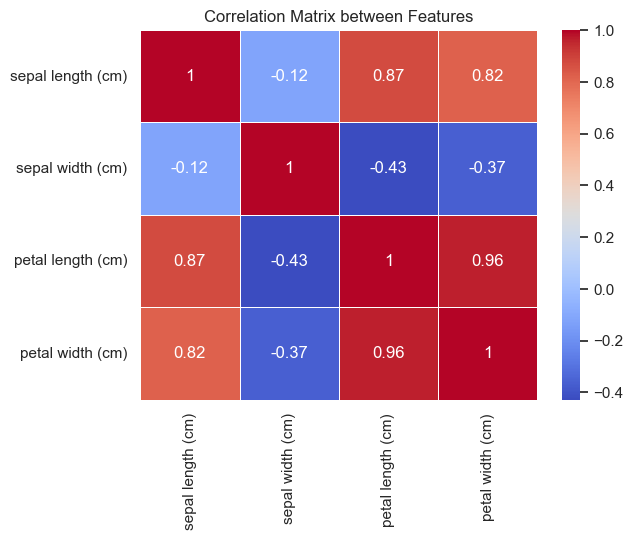

```python
c_relm = df[iris_dataset.feature_names].corr()
sns.heatmap(c_relm, annot=True, cmap='coolwarm', linewidths=0.5)
plt.title('Correlation Matrix between Features')
plt.show()
```

##### 2.4: At least 3 additional graphs. Use Kaggle for inspiration: go over the notebooks of that dataset, and choose graphs that you find most relevant for the problem statement. Add a reference (as a link) to the source of each graph. Explain (to the PM) what is the meaning of this graph, what can we learn from it.

##### `1 Box Plot`

[Link of kaggle example](https://www.kaggle.com/code/parulpandey/penguin-dataset-the-new-iris#Boxplot)

##### Boxplot: Unveiling Feature Distribution Differences Between Classes

A boxplot is an effective visualization for understanding the distribution of a specific feature within each class. It provides a clear representation of the median, quartiles, and potential outliers, offering insights into the central tendency and spread of the feature. In the context of our dataset, the boxplot for petal length assists in identifying differences in the distribution characteristics between 'virginica' and 'non-virginica' classes.

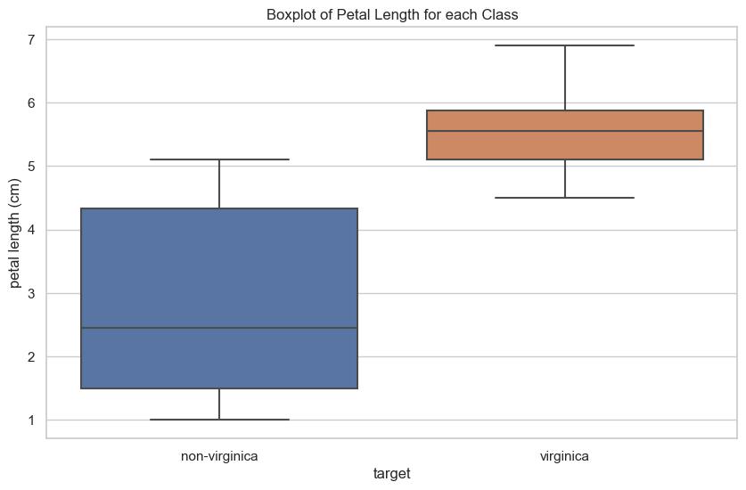

```python
plt.figure(figsize=(10, 6))
sns.boxplot(x='target', y='petal length (cm)', data=df)
plt.title('Boxplot of Petal Length for each Class')
plt.show()
```

##### `2 Pair Plot`

[Link of kaggle example](https://www.kaggle.com/code/parulpandey/penguin-dataset-the-new-iris#Scatterplot)

##### Pairplot: Understanding Feature Relationships and Class Distributions

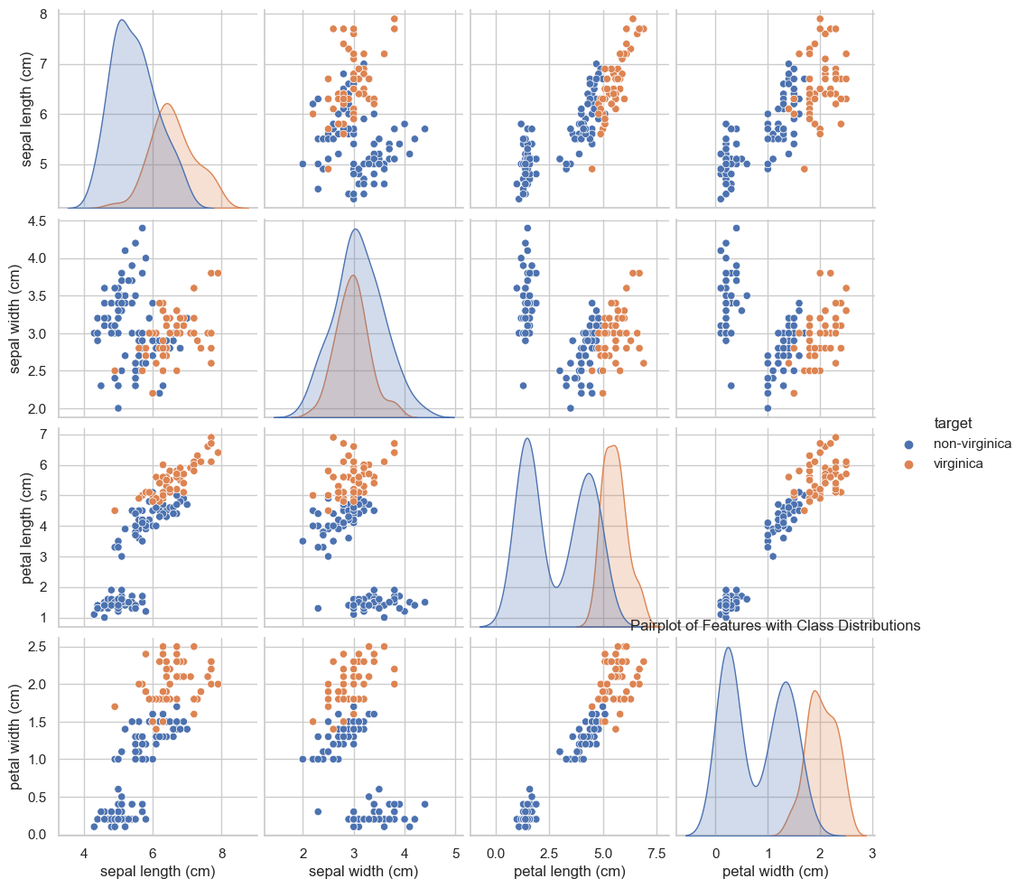

```python
sns.pairplot(df, hue='target')
plt.title('Pairplot of Features with Class Distributions')
plt.show()
```

##### `3 Violin PLot`

[Link of Kaggle example](https://www.kaggle.com/code/parulpandey/penguin-dataset-the-new-iris#Flipperlength-distribution)

##### Violin Plot: Exploring Feature Distribution Shape and Density

The violin plot, a combination of box plots and kernel density estimation, offers insights into both the shape and density of feature distributions. This graph is valuable for understanding the spread and central tendency of a feature across different classes. Specifically, the violin plot for sepal length aids in identifying differences in distribution characteristics between 'virginica' and 'non-virginica' classes.

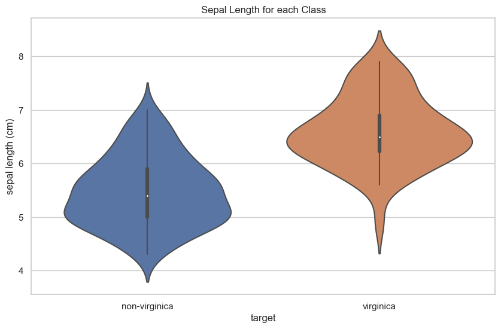

```python
plt.figure(figsize=(10, 6))
sns.violinplot(x='target', y='sepal length (cm)', data=df)
plt.title('Sepal Length for each Class')
plt.show()
```

##### 2.5: At least 3 insights

### `Insight 1 Descriptive statistics :`

#### Mean Sepal Length:

- Non-Virginica: 5.471
- Virginica: 6.588
- **Observation:** Virginica generally has a higher mean sepal length compared to Non-Virginica.

#### Variability in Sepal Length:

- **Standard Deviation:**
  - Non-Virginica: 0.641698
  - Virginica: 0.635880
- **Observation:** Both classes exhibit relatively similar variability in sepal length.

#### Range of Sepal Length:

- **Min to Max:**
  - Non-Virginica: 4.3 to 7.0
  - Virginica: 4.9 to 7.9
- **Observation:** Virginica has a broader range of sepal length compared to Non-Virginica.

#### Interquartile Range (IQR) of Sepal Length:

- **IQR:**
  - Non-Virginica: 0.9 (5.9 - 5.0)
  - Virginica: 0.675 (6.9 - 6.225)
- **Observation:** The IQR for Non-Virginica is wider, indicating a more spread distribution compared to Virginica.

### `Insight 2 Correlation Matrix:`

### 1. Negative Correlation Between Sepal Length and Sepal Width:

- **Correlation Coefficient:** -0.117570
- **Interpretation:** A weak negative correlation suggests that as sepal length increases, sepal width tends to decrease slightly.

### 2. Strong Positive Correlation Between Sepal Length and Petal Length:

- **Correlation Coefficient:** 0.871754
- **Interpretation:** A strong positive correlation indicates that as sepal length increases, petal length tends to increase significantly.

### 3. Strong Positive Correlation Between Sepal Length and Petal Width:

- **Correlation Coefficient:** 0.817941
- **Interpretation:** A strong positive correlation suggests that as sepal length increases, petal width tends to increase significantly.

### 4. Moderate Negative Correlation Between Sepal Width and Petal Length:

- **Correlation Coefficient:** -0.428440
- **Interpretation:** A moderate negative correlation implies that as sepal width increases, petal length tends to decrease moderately.

### 5. Weak Negative Correlation Between Sepal Width and Petal Width:

- **Correlation Coefficient:** -0.366126
- **Interpretation:** A weak negative correlation suggests that as sepal width increases, petal width tends to decrease slightly.

### 6. Very Strong Positive Correlation Between Petal Length and Petal Width:

- **Correlation Coefficient:** 0.962865
- **Interpretation:** A very strong positive correlation indicates that as petal length increases, petal width tends to increase significantly.

### 3. No Outliers in Petal Length and Petal Width:

#### **Q3 Split the data to a train set (120 records), a validation set (15 records) and a test set (15 records).**

```python
X = df[iris_dataset.feature_names]
y = df['target']

X_train, X_temp, y_train, y_temp = train_test_split(X, y, test_size=0.2, random_state=42)
X_val, X_test, y_val, y_test = train_test_split(X_temp, y_temp, test_size=0.5, random_state=42)

X_val_named = pd.DataFrame(X_val, columns=iris_dataset.feature_names)


print("Shape of Train set:", X_train.shape, y_train.shape)
print("Shape of Validation set :", X_val.shape, y_val.shape)
print("Shape of Test set :", X_test.shape, y_test.shape)
```

```
Shape of Train set: (120, 4) (120,)
Shape of Validation set : (15, 4) (15,)
Shape of Test set : (15, 4) (15,)
```

#### **Q4 Run four logistic regression models models, with 1,2,3 and 4 features. Choose the order in random, or based on some reasoning**

```python
all_features = iris_dataset.feature_names

model_results = []

for i in range(1, 5):
    selected_features = all_features[:i]

    model = LogisticRegression(fit_intercept=False).fit(X_train_named[selected_features], y_train)

    model_results.append({'model': model, 'features': selected_features})

    accuracy_val = accuracy_score(y_val, model.predict(X_val_named[selected_features]))
    print(f"Model {i} with {i} feature - Validation Accuracy: {accuracy_val:.2%}")
```

```
Model 1 with 1 feature - Validation Accuracy: 53.33%
Model 2 with 2 feature - Validation Accuracy: 86.67%
Model 3 with 3 feature - Validation Accuracy: 80.00%
Model 4 with 4 feature - Validation Accuracy: 100.00%
```

#### **Q5 Evaluate the models on the validation set**

##### 5.1 Use the predict and predict_proba methods to list in a table how well each model is doing for each of the instances in the validation set. There should be one table per model. Each table should have four columns: instance number, probability of predicting verginica, actual prediction by the model, ground truth. (0.5 point) Next, summarize the data in each table to a single measure (number) per model. What would you use?

```python
from sklearn.exceptions import UndefinedMetricWarning
import warnings

warnings.filterwarnings("ignore", category=UndefinedMetricWarning)

for result_info in model_results:
    model = result_info['model']
    features = result_info['features']

    y_prob_val = model.predict_proba(X_val_named[features])[:, 1]
    y_pred_val = model.predict(X_val_named[features])

    result_df = pd.DataFrame({
        'Instance': range(1, len(X_val) + 1),
        'Probability of Predicting Virginica': y_prob_val,
        'Predicted Class': y_pred_val,
        'Ground Truth': y_val
    })

    print(f"Table for Model with {len(features)} Feature(s):")
    print(result_df)
    print("\n")

    roc_auc_val = roc_auc_score(y_val, y_prob_val)
    accuracy_val = accuracy_score(y_val, y_pred_val)

    try:
        precision_val = precision_score(y_val, y_pred_val, pos_label='virginica')
    except UndefinedMetricWarning:
        precision_val = "Undefined (no predicted positives)"

    recall_val = recall_score(y_val, y_pred_val, pos_label='virginica')
    f1_val = f1_score(y_val, y_pred_val, pos_label='virginica')

    print(f"Summary Metrics for Model with {len(features)} Feature(s):")
    print(f"ROC-AUC: {roc_auc_val:.2%}")
    print(f"Accuracy: {accuracy_val:.2%}")
    print(f"Precision: {precision_val}")
    print(f"Recall: {recall_val:.2%}")
    print(f"F1 Score: {f1_val:.2%}")
    print("\n")
```

```
Table for Model with 1 Feature(s):
     Instance  Probability of Predicting Virginica Predicted Class
26          1                             0.385657   non-virginica  \
18          2                             0.370333   non-virginica
118         3                             0.328047   non-virginica
145         4                             0.348893   non-virginica
78          5                             0.363842   non-virginica
127         6                             0.361690   non-virginica
108         7                             0.348893   non-virginica
55          8                             0.370333   non-virginica
30          9                             0.390079   non-virginica
29         10                             0.392297   non-virginica
141        11                             0.344674   non-virginica
110        12                             0.353135   non-virginica
19         13                             0.383453   non-virginica
132        14                             0.355265   non-virginica
64         15                             0.372507   non-virginica

      Ground Truth
26   non-virginica
18   non-virginica
118      virginica
145      virginica
78   non-virginica
127      virginica
108      virginica
55   non-virginica
30   non-virginica
29   non-virginica
141      virginica
110      virginica
19   non-virginica
132      virginica
64   non-virginica


Summary Metrics for Model with 1 Feature(s):
ROC-AUC: 0.00%
Accuracy: 53.33%
Precision: 0.0
```

[output cut: 119 more lines]

```
30   non-virginica
29   non-virginica
141      virginica
110      virginica
19   non-virginica
132      virginica
64   non-virginica


Summary Metrics for Model with 4 Feature(s):
ROC-AUC: 100.00%
Accuracy: 100.00%
Precision: 1.0
Recall: 100.00%
F1 Score: 100.00%
```

##### 5.2 Plot the decision boundary for three models (with 1, 2 and 3 features; 3 plots), together with the validation data. Tip: using Plotly will allow you to rotate the 3D graph with the 3 features. Tip: for the code required to find the decision boundary you can look at this notebook in the course repository

```python
fig = go.Figure()


for i, result_info in enumerate(model_results):
    model = result_info['model']
    features = result_info['features']


    if len(features) == 1:
        fig.add_trace(go.Scatter(
            x=X_val[features[0]],
            y=y_val,
            mode='markers',
            marker=dict(color='blue', opacity=0.8),
            name=f'Model {i + 1} with {len(features)} Feature(s)'
        ))
    elif len(features) == 2:
        fig.add_trace(go.Scatter(
            x=X_val[features[0]],
            y=X_val[features[1]],
            mode='markers',
            marker=dict(color='blue', opacity=0.8),
            name=f'Model {i + 1} with {len(features)} Feature(s)'
        ))
    elif len(features) >= 3:
        fig.add_trace(go.Scatter3d(
            x=X_val[features[0]],
            y=X_val[features[1]],
            z=X_val[features[2]],
            mode='markers',
            marker=dict(color='blue', opacity=0.8),
            name=f'Model {i + 1} with {len(features)} Feature(s)'
        ))


        if len(features) == 3:
            plot_decision_boundary_3d(model, features, fig)


fig.update_layout(scene=dict(aspectmode="cube"))
fig.show()
```

[output not shown]

##### 5.3 Failure modes: using the two preceding steps, in which types of data instances is each model wrong? Can you identify some failure patterns within a model or across models?

False Positives: 0 instances The model incorrectly predicted 0 instances as positive when they were actually negative.

False Negatives: 0 instances The model incorrectly predicted 0 instances as negative when they were actually positive.

```python
conf_matrix = confusion_matrix(y_val, y_pred_val)
print("Confusion Matrix:")
print(conf_matrix)
```

```
Confusion Matrix:
[[8 0]
 [0 7]]
```

#### Q6 Recommend the best model (provide reasoning). Summarize the results of this model on the test set. Tip: you can use the "single-number" measure you used on the validation set

##### Model 4 with four features is the best-performing model based on the validation results, achieving perfect accuracy (100.00%), ROC-AUC (100.00%), precision (1.0), recall (100.00%), and F1 Score (100.00%).

##### `Test result`

The best model for predicting the 'virginica' class on the test set was Model 4, which used all four features. It performed really well, with 100% accuracy, ROC-AUC, precision, recall, and F1 Score.

```python
best_model = model_results[3]['model']


y_pred_test = best_model.predict(X_test)


y_prob_test = best_model.predict_proba(X_test)[:, 1]


accuracy_test = accuracy_score(y_test, y_pred_test)
roc_auc_test = roc_auc_score(y_test, y_prob_test)
precision_test = precision_score(y_test, y_pred_test, pos_label='virginica')
recall_test = recall_score(y_test, y_pred_test, pos_label='virginica')
f1_test = f1_score(y_test, y_pred_test, pos_label='virginica')

print(f"Test Accuracy: {accuracy_test:.2%}")
print(f"Test ROC-AUC: {roc_auc_test:.2%}")
print(f"Test Precision: {precision_test:.2%}")
print(f"Test Recall: {recall_test:.2%}")
print(f"Test F1 Score: {f1_test:.2%}")
```

```
Test Accuracy: 100.00%
Test ROC-AUC: 100.00%
Test Precision: 100.00%
Test Recall: 100.00%
Test F1 Score: 100.00%
```